# HW3

Zsiros, Gabriella

2023-02-21

# Introduction

The target is to predict the growth of firms in `cs_bisnode_panel.csv` dataset, which contains several variables about firms, including balance sheet, income statement, HQ and CEO information.

The original data range spans from 2005 to 2016.

In this exercise, that data will be narrowed down from 2010 to 2015.

Binary variables, such as region, CEO’s gender and urban locations are factorized.

Columns that are less than 90% complete are dropped.

Missing variables are imputed through the mean of numerical values, and the mode of binary variables.

One determining feature is sales data. The natural logarithm is calculated to calculate growth rate in each year. Sales is also transformed to be expressed in millions.

Balance sheet variables were also examined, those which should not contain negative values, such as assets.

```
##
##      0      1
## 128106     83
```

Income statment and balance sheet variables are grouped and normalized by sales and total asset value.

Variables without variance are also flagged, then eliminated.

```
##          1%          5%         10%         25%         50%         75%
## 0.000000000 0.000000000 0.000000000 0.004159259 0.031914814 0.126618523
##         90%         95%         99%
## 0.466205938 0.923605547 5.673363875
```

The data filtered tot he target year now has 68 variables and 26k observations.

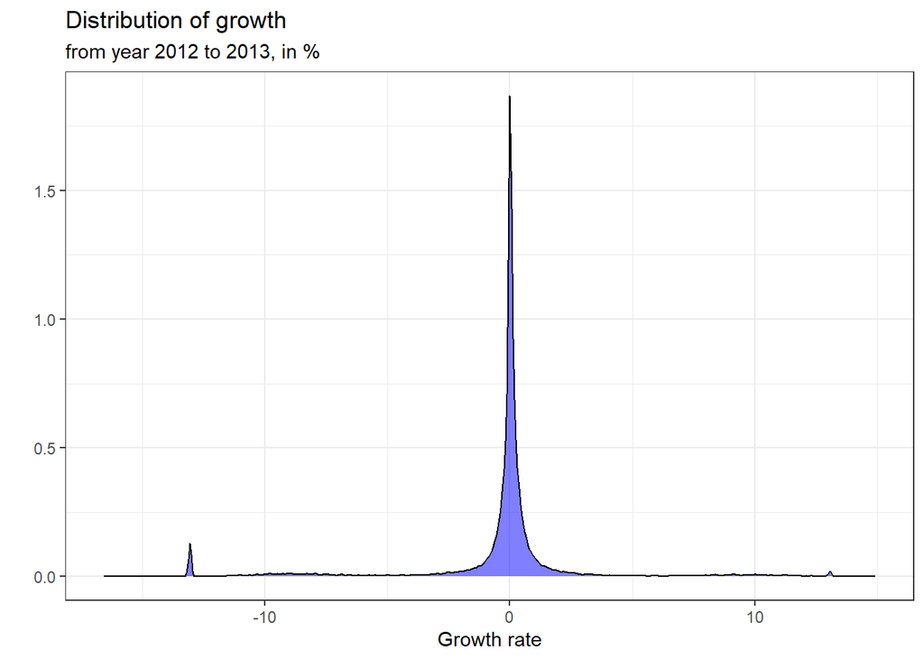

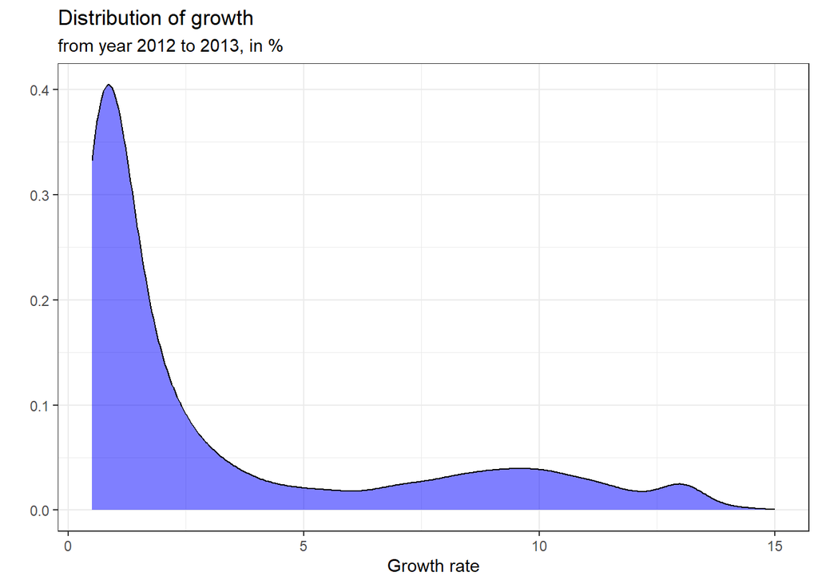

```
##        50%        75%        80%        85%        90%        95%        99%
##  0.0000000  0.2577827  0.3868940  0.6037251  1.0881297  3.1952465 11.1287373
```

Based on distribution of the sales growth data, growth rate above 35% will be considered as fast growth

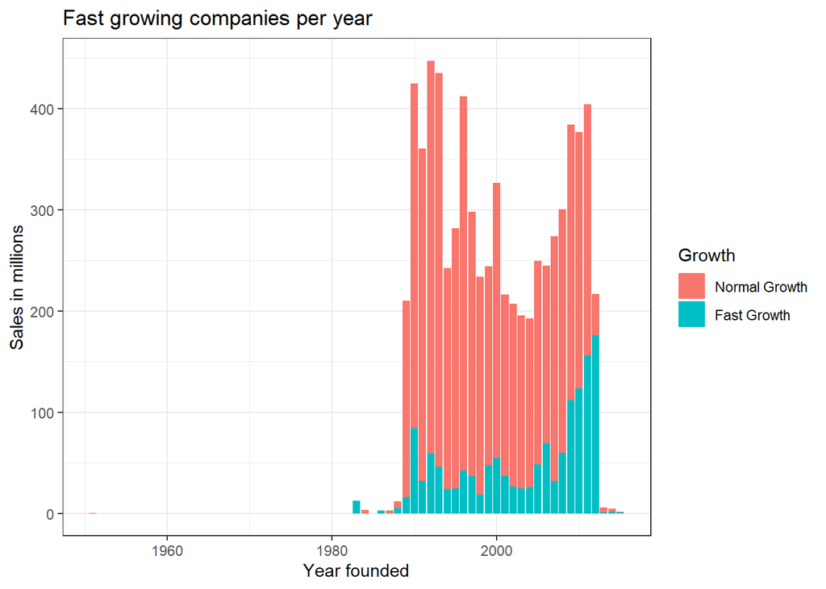

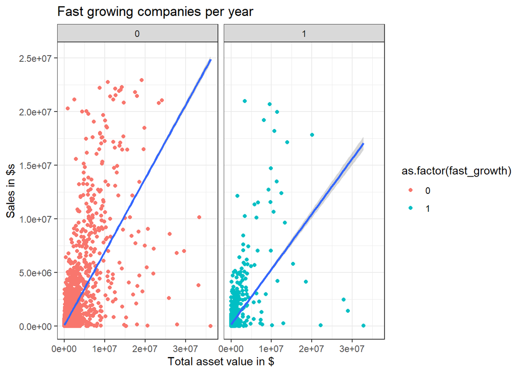

# PART I: Probability prediction

## Probability prediction

Predicting probabilities

Five combination of variables are considered, each being more complex than the previous one. The starting point is simple financial data. The second level includes quadratic term, as well as more details about the firm. The third level add balance sheet and income statement variables. The fourth level includes variables of the CEO, and the fifth is completed by interaction terms.

The dataset is split into a holdout (20%, n = 5207) and training (80%, n = 20830) subset.

## Probability

Logit probability prediction is calculated and cross-validated through 5 folds.

### Linear

The logit probability model is run across 5 folds, testing each variables combination X1 through X5

By calculating the average ROC across folds, model X4 has the highest score: 0.72.

```
## [1] "Model: X1, Mean CV ROC: 0.628148785116198"
## [1] "Model: X2, Mean CV ROC: 0.701091407330525"
## [1] "Model: X3, Mean CV ROC: 0.728170486641647"
## [1] "Model: X4, Mean CV ROC: 0.728308887066775"
## [1] "Model: X5, Mean CV ROC: 0.727309995552693"
```

### Lasso

For Lasso Parameters, the lambda was set as 10-based logarithmic set of parameters, from -1.

```
## [1] "Model: X4, Mean CV ROC: 0.728308887066775"
## [1] "Model: LASSO, Mean CV ROC: 0.728232170099543"
```

### Random Forest

With Random Forest turning, the model iterates through 6, 8 and 10 tree numbers, which results in 6 variables being the most optimal set-up.

AUC values are then calculated with ROC function.

```
##       Number.of.predictors    CV.ROC    CV.AUC
## X1                       4 0.6281488 0.6281488
## X2                      10 0.7010914 0.7010914
## X3                      23 0.7281705 0.7281705
## X4                      31 0.7283089 0.7283089
## X5                      40 0.7273100 0.7273100
## LASSO                   29 0.7282322 0.7074976
## rf_p                    40 0.8057376 0.8047589
```

The best logit result without considering a loss function is the random forest model. When testing on the holdout dataset, it has a very good RMSE value:

```
## [1] 0.3611022
```

# PART II: Classification

## Loss function

When defining the loss function, it must be considered, that false positive mean we might invest into a firm which will not have large ROI, but this also has an opportunity cost of not investing that money to a firm that would have been growing fast. False negative means that we missed out on an opportunity to invest. Therefor the ratio is determined as 2:1 (FP/FN)

## Classification threshold

During classification, the most optimal threshold is determined through 5-fold cross validation. Two factors are playing an important role: the prevalence and the cost. Prevalence shows the proportion of the positive (TP+FP) in the dataset, while the cost reflects the ratio of False Positive and False Negative.

In this case, the Random Forest model determines the threshold at 0.569, very similar to the first linear model.

## Average exprected loss

It is visible that the threshold is much higher if we use more complex linear models. Random Forest gives similar result to the first, simple variable model. The average expected loss is produced with random forest, with 0.193, while the rest of the models perform around 0.21

```
##      Avg of optimal thresholds Avg expected loss
## [1,] 0.5691508                 0.2120236
## [2,] 0.7128088                 0.2118314
## [3,] 0.7797533                 0.2119756
## [4,] 0.7819325                 0.2119756
## [5,] 0.7811263                 0.2119756
## [6,] 0.7401033                 0.2119996
## [7,] 0.5692295                 0.1934259
```

# PART III Discussion of results

## Evaluation

Testing the models on the holdout set, the best optimal threshold is set by random forest at 0. 569, since this results in the lowest expected loss. Using this, the model proves to be a good fit on the holdout set, the expected loss is 0.203.

```
## [1] 0.2033833
```

## Confusion table

```
##                  Reference
## Prediction        not_fast_growth fast_growth
##   not_fast_growth            3984         852
##   fast_growth                 103         263
```